# Data Exploration on Data Expo 2009: Airline on time data

## by Houssem Menhour

## Investigation Overview

In this presentation, I'll be showcasing some key findings from my EDA process on the dataset described bellow.

My main interest is investigating flight delay times in relation to other vaiables.

## Dataset Overview

In this project I'll analyze and visualize my findings on the flights dataset suggested by Udacity, with a focus on the time period from 2000 to 2002.

The provided link does not lead to an easily downloadable source, so I used [Harvard Dataverse](https://dataverse.harvard.edu/dataset.xhtml?persistentId=doi:10.7910/DVN/HG7NV7) as an alternative source to get the data.

## Cancelled and Diverted Flights

A total of 3.1% of all flights has been either cancelled or diverted.

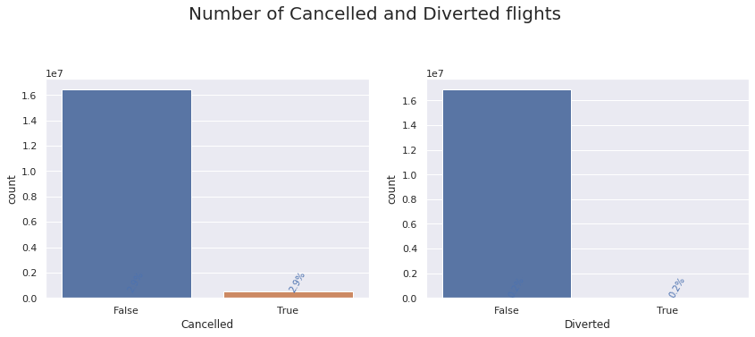

```python
cols_interest = ['Cancelled', 'Diverted']

f = plt.figure(figsize=(12, 8))
gs = f.add_gridspec(len(cols_interest), 2)
for i, col in enumerate(cols_interest):
    ax = f.add_subplot(gs[int(i/2),i%2])
    #sns.boxplot(df2[col], kind="box");
    ax = sns.countplot(df2[col])
    ax.set_xticklabels(ax.get_xticklabels())
    #sns.distplot(df2[col], kde=False);
    # add annotations
    n_points = df2.shape[0]
    col_counts = df2[col].value_counts()
    locs, labels = plt.xticks() # get the current tick locations and labels

    # loop through each pair of locations and labels
    for loc, label in zip(locs, labels):

        # get the text property for the label to get the correct count
        count = col_counts[bool(label.get_text())]
        pct_string = '{:0.1f}%'.format(100*count/n_points)

        # print the annotation just below the top of the bar
        plt.text(loc, count+10, pct_string, ha = 'left', color = 'b', rotation=60, fontsize=10)

f.suptitle('Number of Cancelled and Diverted flights', fontsize=20, y = 1.1)
f.tight_layout()
```

## Flights distribution per Carrier

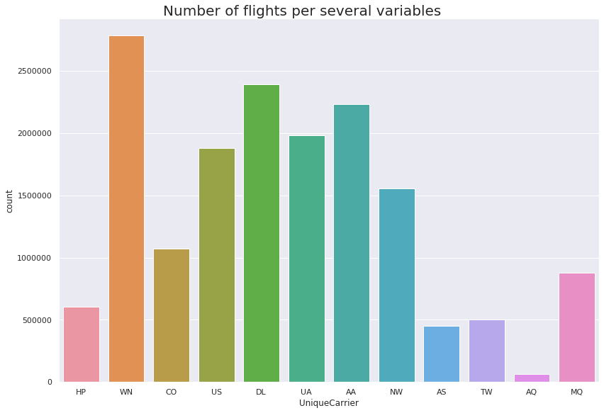

```python
f = plt.figure(figsize=(12, 8))
ax = sns.countplot(df3['UniqueCarrier'])
f.suptitle('Number of flights per several variables', fontsize=20, y = 1.01)
f.tight_layout()
```

## Flight distance and air time distribution

- Most flights are relatively short which is to be expected considering that the data is only for US domestic flights.

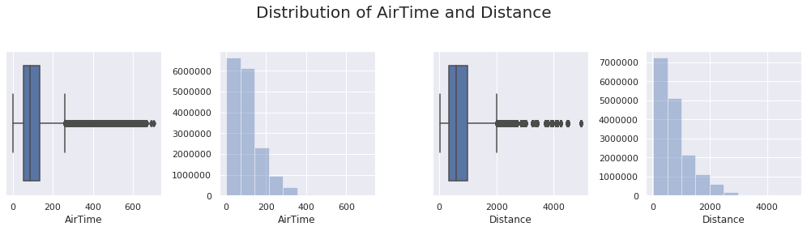

```python
cols_interest = ['AirTime', 'Distance']

f = plt.figure(figsize=(14, 6))
gs = f.add_gridspec(len(cols_interest), 4)
for i, col in enumerate(cols_interest):
    ix, iy= int(i/2), (2 if i%2 else 0)
    ax = f.add_subplot(gs[ix,iy])
    ax = sns.boxplot(df3[col]);
    ax = f.add_subplot(gs[ix,iy+1])
    ax = sns.distplot(df3[col], bins = 10, kde=False);

f.suptitle('Distribution of AirTime and Distance', fontsize=20, y = 1.1)
f.tight_layout()
```

## DepDelay and ArrDelay Distribution

- While most flights take of on time or with minor delays, there is still a significant number of outliers with very long delay times.
- Zooming in on the distribution only strengthens the earlier notion.

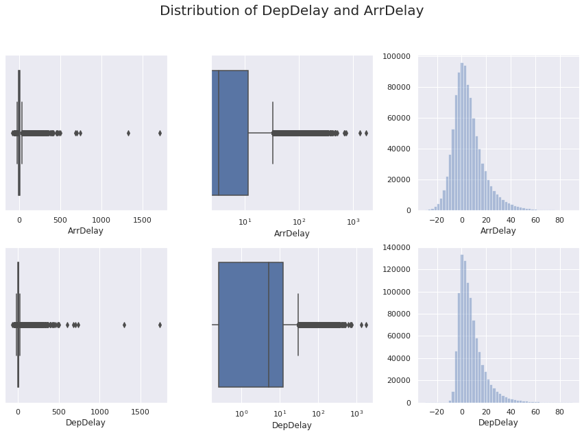

```python
cols_interest = ['ArrDelay', 'DepDelay']

f = plt.figure(figsize=(12, 8))
gs = f.add_gridspec(len(cols_interest), 3)
for i, col in enumerate(cols_interest):

    ax = f.add_subplot(gs[i,0])
    ax = sns.boxplot(df_agg[col]);

    ax = f.add_subplot(gs[i,1])
    ax = sns.boxplot(df_agg[col]);
    ax.set(xscale="log");

    ax = f.add_subplot(gs[i,2])
    ax = sns.distplot(df_agg[col], kde=False, hist_kws={"range": [-30,90]});

f.suptitle('Distribution of DepDelay and ArrDelay', fontsize=20, y = 1.1)
f.tight_layout()
```

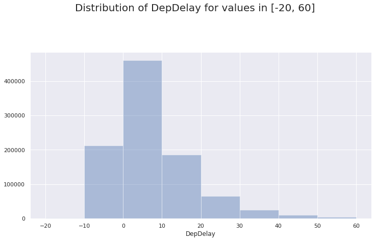

```python
f, ax = plt.subplots(figsize=(12, 6))
ax = sns.distplot(df_agg['DepDelay'], bins = 8, kde=False, hist_kws={"range": [-20,60]});
f.suptitle('Distribution of DepDelay for values in [-20, 60]', fontsize=20, y = 1.1)
plt.show()
```

## Finding Correlations

- There are no strong correlations between ArrDelay, DepDelay and other variables, we need to investigate further.

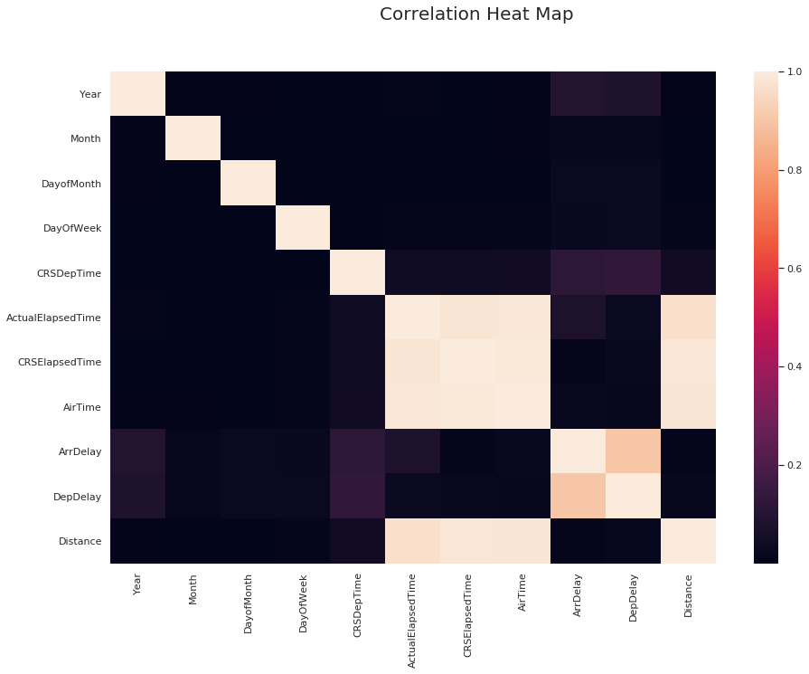

```python
#Plot the heatmap with seaborn
plt.figure(figsize=(15,10))
sns.heatmap(corr_mat,
        xticklabels=corr_mat.columns,
        yticklabels=corr_mat.columns);

plt.suptitle('Correlation Heat Map', fontsize=20);
```

## DepDelay vs Categorical variables

- Interesting, while the correlation is not that strong as mentioned earlier, it seems that the first days of every week, and of every month see slightly less delays then the rest.
- We also see an overal improvement year over year.

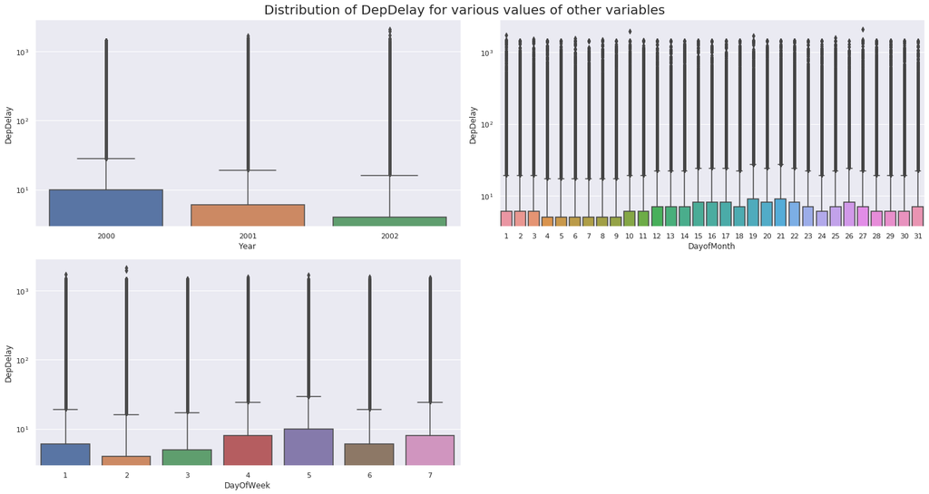

```python
cols_interest = ['Year', 'DayofMonth', 'DayOfWeek']

f = plt.figure(figsize=(20, 15))
gs = f.add_gridspec(len(cols_interest), 2)
for i, col in enumerate(cols_interest):
    ax = f.add_subplot(gs[int(i/2),i%2])
    #sns.boxplot(df2[col], kind="box");
    ax = sns.boxplot(x=col, y="DepDelay", data=df3)
    ax.set(yscale="log");
    #sns.distplot(df2[col], kde=False);
    ax.set_xticklabels(ax.get_xticklabels())

f.suptitle('Distribution of DepDelay for various values of other variables', fontsize=20, y = 1.01)
f.tight_layout()
```

## AirTime vs Distance

Comes as no surprise, showing that distance and airtime have indeed a direct correlation.

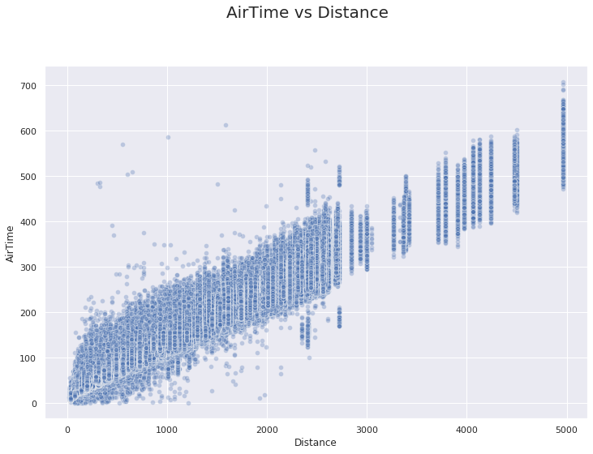

```python
f = plt.figure(figsize=(12, 8))
ax = sns.scatterplot(x='Distance', y="AirTime", data=df3, alpha = 0.3);
f.suptitle('AirTime vs Distance', fontsize=20, y = 1.01);
```

## Flight numbers over time

A sharp dip in the number of flights since September 2001, a direct result of the 9/11 attacks.

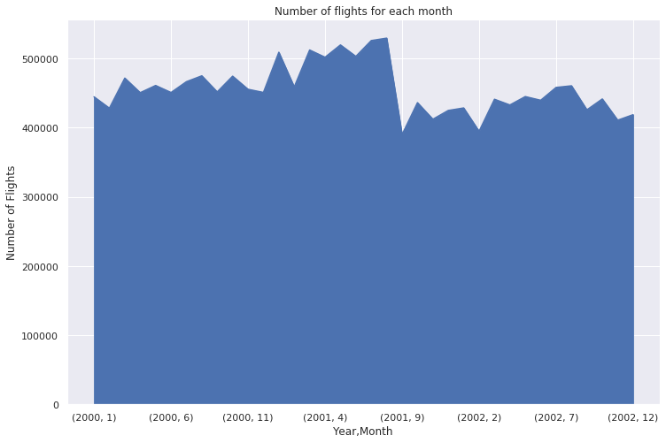

```python
ax = df_tmp.drop(['DepDelay'], axis = 1).plot(figsize=(12,8), kind = 'area', legend = False, title = "Number of flights for each month")
ax.set(ylabel="Number of Flights");
```

## Delay Averages over time

- Seems like delays spike up in june and december of each year, which aligns perfectly with summer and end of year holidays.
- Since previous exploration showed us no difference in the number of flights, it might be a an indicator of a higher number of passengers and more crowded flights.

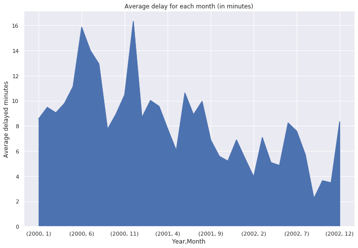

```python
ax = df_tmp.drop(['NumberofFlights'], axis = 1).plot(figsize=(12,8), kind = 'area', legend = False, title = "Average delay for each month (in minutes)")
ax.set(ylabel="Average delayed minutes");
```

## DepDelays per Carrier and Year

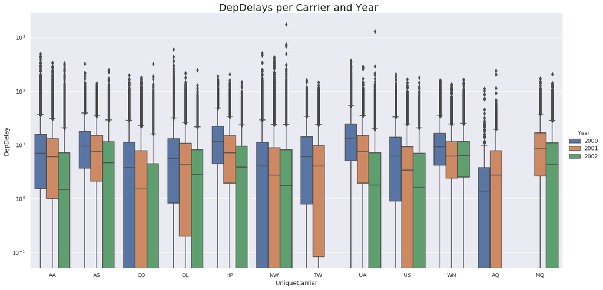

```python
g = sns.catplot(x="UniqueCarrier", y="DepDelay", hue="Year", kind="box", data=df_agg, height=8, aspect=2);
g.set(yscale="log");
g.fig.suptitle('DepDelays per Carrier and Year', fontsize=20, y = 1.01);
```

## DepDelays during September 2001

- Flights came to a hold on the 9/12th of 2001.
- They started again the following day but with significantly more delaysthan usual.

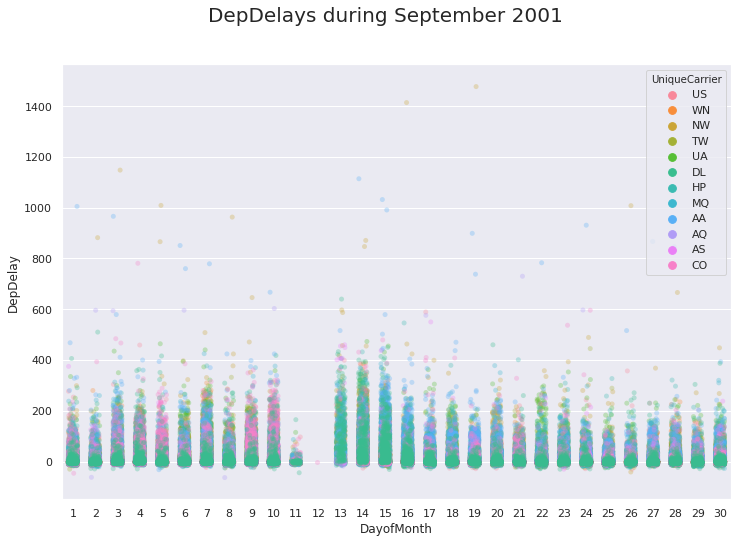

```python
f = plt.figure(figsize=(12, 8))
#ax = sns.scatterplot(x='DayofMonth', y="DepDelay", hue='UniqueCarrier', size='Distance', sizes=(10, 100),  data=df_tmp3, alpha = 0.5)
ax = sns.stripplot(x='DayofMonth', y="DepDelay", hue='UniqueCarrier', data=df_tmp3, alpha = 0.3, jitter = 0.2)
f.suptitle('DepDelays during September 2001', fontsize=20);
```